CRISPR screening in AML

# Genome-wide CRISPR screening in murine AML

## Abstract

The mutational landscape of AML has powerfully guided the development of targeted therapies, yet many in vivo phenotypic features of the disease are not fully explained by genomic analysis. We report two genome-wide CRISPR screens in vivo in murine models of AML, driven by the MLL/AF9 fusion protein or constitutive co-expression of HoxA9 and Meis1. A secondary, focused in vivo validation screen identified 72 genes specifically essential to leukemic growth in vivo, with significant overlap between both models. To further identify which genes regulate AML growth in vivo, we compared to transcriptomic analysis in a fluorescent clonal competition model of MLL/AF9 AML. Consistent alterations in mTORC1 signaling, oxidative phosphorylation, targets of MYC and cholesterol synthesis were evident among growth-advantaged clonal populations. So far as we know, this is the first genome-wide in vivo CRISPR screen reported for AML. Overall, these data demonstrate the feasibility of genome-wide functional screens in vivo and their utility to identify metabolic pathways and immune inhibitory genes relevant for cancer control.

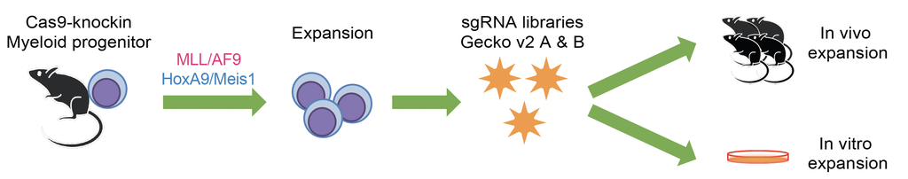

Shanghai Institute of Biochemistry and Cell Biology, Center for Excellence in Molecular Cell Science, CAS